# May21Analysis

```r
# Load packages
library(tidyverse)
```

```r
library(ggplot2)
library(readxl)
library(lubridate)
library(broom)
library(viridis)
library(tsModel)
library(scales)
library(grid)
library(tseries)
library(tsibble)
library(fable)
library(feasts)
library(forecast)

# Global options
knitr::opts_chunk$set(echo = TRUE, warning = FALSE, message = FALSE)
```

This contains all code used to analyze the datasets found in the `/CleanData` directory, which were previously generated in the `/Scripts/Cleaning.rmd` file.

# 1 Introduction

This analysis will replicate the ARIMAs, this time changing the “interruption period” to be in May 2021, when Bill 8 was ruled rather than enacted.

# 2 Descriptive Statistics

# 3 15-44 Texan Female Deaths by Assault

## 3.1 Using Rpubs Tidy version

From this [RPubs article](https://rpubs.com/jcorbin/tidy_itt_arima)

Uploading data and converting to a tsibble object:

```r
monthly <- read.csv("../CleanData/monthly_f.csv")
monthly.ts <- monthly %>%
  select(-sex) %>%
  mutate(month_year = ymd(month_year),
         month = yearmonth(month_year)) %>%
  as_tsibble(index = month)

glimpse(monthly.ts)
```

```
## Rows: 72
## Columns: 5
## $ Deaths     <int> 16, 16, 17, 26, 17, 11, 19, 20, 23, 15, 21, 22, 10, 24, 23,…
## $ month_year <date> 2018-01-01, 2018-02-01, 2018-03-01, 2018-04-01, 2018-05-01…
## $ bill8      <lgl> FALSE, FALSE, FALSE, FALSE, FALSE, FALSE, FALSE, FALSE, FAL…
## $ time       <int> 1, 2, 3, 4, 5, 6, 7, 8, 9, 10, 11, 12, 13, 14, 15, 16, 17, …
## $ month      <mth> 2018 Jan, 2018 Feb, 2018 Mar, 2018 Apr, 2018 May, 2018 Jun,…
```

Looking at data, along with ACF and PACF plots:

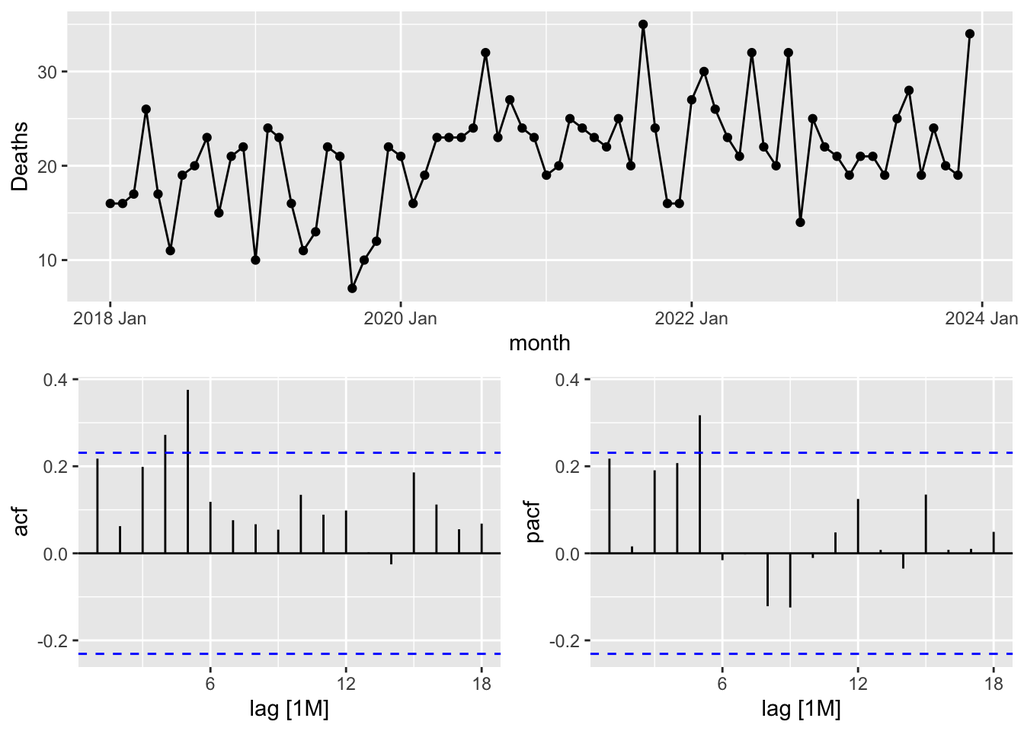

```r
monthly.ts |>
  gg_tsdisplay(y = Deaths, plot_type = "partial")
```

Looking at the PACF and ACF after differencing:

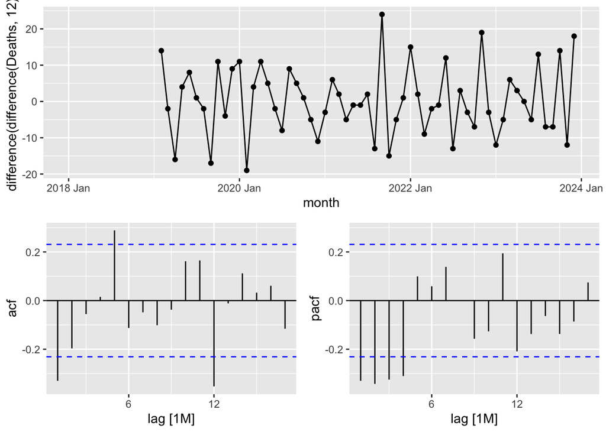

```r
monthly.ts |>
  gg_tsdisplay(y = difference(difference(Deaths,12)), plot_type = "partial")
```

Letting Fable’s ARIMA algorithm choose the best fit…

## 3.2 Intervention effects

we are capturing the intervention effects next - step and ramp variable. The first effect is captured by a step (or level shift) variable, which is a dummy variable that is 0 for all months prior to the intervention and 1 for intervention months. The second is a ramp variable, which is 0 for all months prior to the intervention and starts with 1 on the first month of the intervention and increases by 1 from there (e.g., **May, 2021** = 1; June = 2; etc…)

```r
range(monthly.ts$time)
```

```
## [1]  1 72
```

```r
# Create variable representing step and ramp changes
intervention_month <- monthly.ts %>%
  filter(month_year == "2021-05-01") %>%
  pull(time)
monthly.ts <- monthly.ts %>%
  mutate(
    t = row_number(),
    step = if_else(t >= intervention_month, 1, 0),
    ramp = if_else(t >= intervention_month, t - intervention_month + 1, 0)
  )

#View the step and ramp variables
monthly.ts %>%
  pivot_longer(
    cols = c(step, ramp),
    names_to = "variables",
    values_to = "value"
  ) %>%
  ggplot(aes(x = month_year, y = value, color = variables)) +
  geom_line(linewidth = 1) +
  geom_vline(
    xintercept = as.Date("2021-05-01"),
    linetype = "dashed",
    color = "black"
  ) +
  labs(
    title = "Visualizing Step and Ramp Variables",
    x = "Month",
    y = "Value",
    color = ""
  ) +
  scale_x_date(date_breaks = "1 year", date_labels = "%Y") +
  theme_minimal() +
  theme(
    panel.grid.major.x = element_blank(),
    panel.grid.minor.x = element_blank()
  )
```

[output not shown]

## 3.3 ARIMA model

The Fable algorithm will dictate the model parameters. Next, we plot the residuals, the ACF plot, and a histogram to ensure they approximate a white noise series.

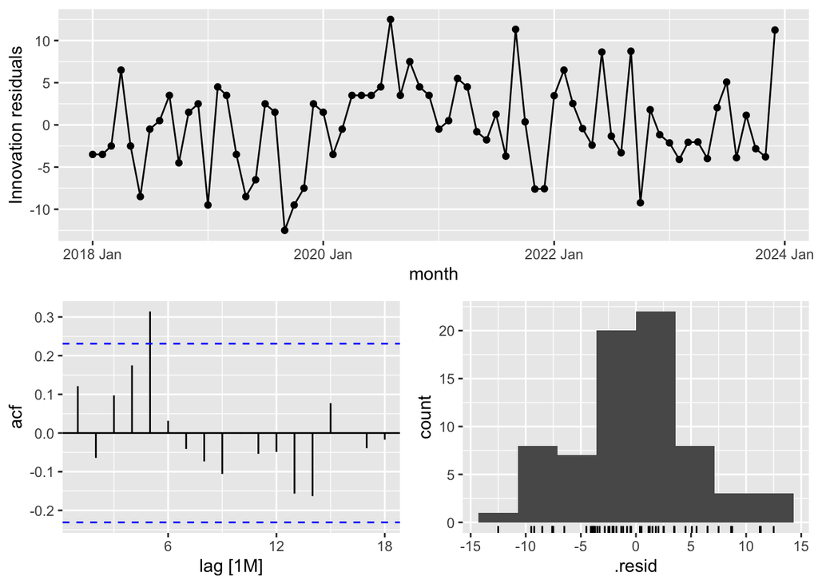

```r
# Use automated algorithm to identify p/q parameters
# Specify first difference = 1 and seasonal difference = 1
m_monthly.ts <- monthly.ts %>%
  model(arima = ARIMA(Deaths ~ step + ramp, stepwise = FALSE))

#Plotting model residuals
m_monthly.ts  %>%
  gg_tsresiduals()
```

Here we use the Ljung-Box test, which models if the residuals are still autocorrelated. Null: residuals are independent (white noise) Alternative: residuals show remaining autocorrelation

```r
#Ljung-Box test
augment(m_monthly.ts) %>%
  features(.resid, ljung_box)
```

```
## # A tibble: 1 × 3
##   .model lb_stat lb_pvalue
##   <chr>    <dbl>     <dbl>
## 1 arima     1.10     0.294
```

We got a p-val of **.29**, meaning we fail to reject the null (there is no evidence of remaining autocorrelation, the ARIMA has adequately captured the time dependence in the data).

With the model assumptions satisfied, we can take a look at the model estimates:

```r
report(m_monthly.ts)
```

```
## Series: Deaths
## Model: LM w/ ARIMA(0,0,0) errors
##
## Coefficients:
##         step     ramp  intercept
##       4.3407  -0.0339    19.5000
## s.e.  2.0628   0.1000     0.8257
##
## sigma^2 estimated as 28.45:  log likelihood=-221.17
## AIC=450.34   AICc=450.94   BIC=459.45
```

It picked up **p=0**, meaning there are no autoregressive terms (the current value is not directly predicted by past raw data values).

**d=0**, meaning there is no differencing; the original, raw data is stationary, possessing no trend.

**q=0**: there is no moving average term, aka the model uses the error from the previous tie step to predict the current value

The ARIMA estimated an immediate increase in **4.3 deaths** and an estimated reduction of **-0.03 deaths** each month after Bill 8 was enacted.

Finally, we can run a counter-factual model in which we forecast deaths for 2021-2023 given the model parameters from our initial model, minus the step and ramp parameters. This gives us a visual of what we would have expected had the new policy not come into existence!

```r
#Modeling counterfactual
m_counterfactual <- monthly.ts %>%
  filter(month < make_yearmonth(2021, 5)) %>%
  model(
    arima_null = ARIMA(
      Deaths,
      stepwise = FALSE
    )
  )
report(m_counterfactual)
```

```
## Series: Deaths
## Model: ARIMA(4,1,0)
##
## Coefficients:
##           ar1      ar2      ar3      ar4
##       -0.6643  -0.7440  -0.5364  -0.2724
## s.e.   0.1540   0.1648   0.1645   0.1539
##
## sigma^2 estimated as 24.02:  log likelihood=-115.86
## AIC=241.72   AICc=243.53   BIC=250.03
```

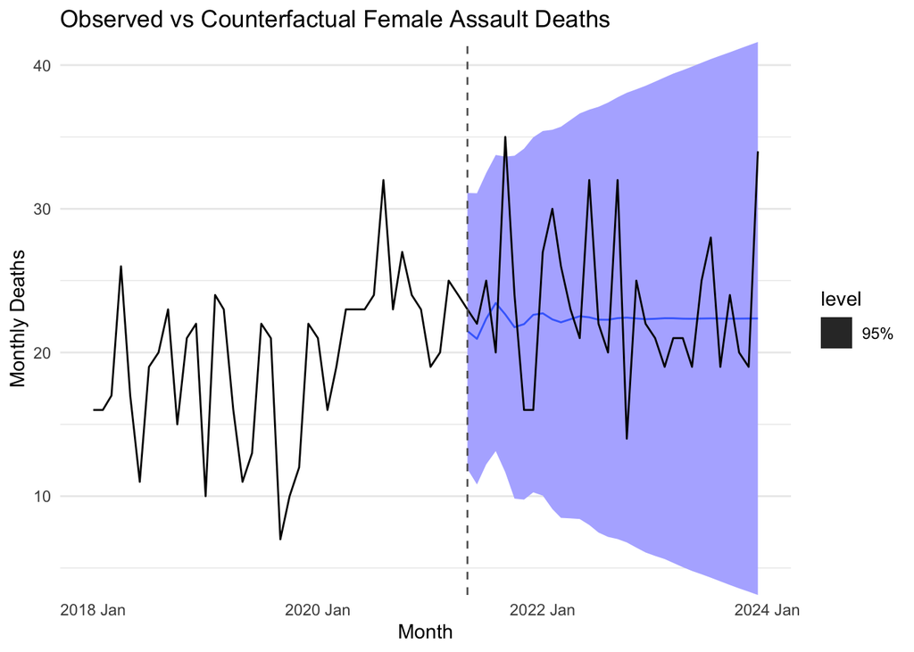

```r
#forecast into post-intervention period
fc_counterfactual <- m_counterfactual %>%
  forecast(h = 28+4) #adding more months to forecast out to

 autoplot(fc_counterfactual, monthly.ts, level = 95) +
  geom_vline(
    xintercept = as.numeric(as_date(make_yearmonth(2021, 5))),
    linetype = "dashed",
    color = "grey40"
  ) +
  labs(
    title = "Observed vs Counterfactual Female Assault Deaths",
    y = "Monthly Deaths",
    x = "Month"
  ) +
  scale_y_continuous(expand = c(0, 0)) +
  theme_minimal() +
  theme(
    panel.grid.major.x = element_blank(),
    panel.grid.minor.x = element_blank()
  )
```

This looks to me as though the month of sept (bill 8 enactment month) is popping, nothing else though.

```r
#just pre-bill 8
auto_monthly.ts <- monthly.ts %>%
  filter(month < make_yearmonth(2021, 5)) %>%
  select(Deaths) %>%
  auto.arima()

summary(auto_monthly.ts)
```

```
## Series: .
## ARIMA(0,1,1)
##
## Coefficients:
##           ma1
##       -0.7490
## s.e.   0.1193
##
## sigma^2 = 27.14:  log likelihood = -119.61
## AIC=243.22   AICc=243.55   BIC=246.55
##
## Training set error measures:
##                     ME     RMSE      MAE       MPE     MAPE      MASE
## Training set 0.6439931 5.077312 4.190982 -5.466336 26.14284 0.5987117
##                    ACF1
## Training set 0.09179102
```

```r
#all data points
auto_monthly.ts2 <- monthly.ts %>%
  select(Deaths) %>%
  auto.arima()

summary(auto_monthly.ts2)
```

```
## Series: .
## ARIMA(0,1,1)
##
## Coefficients:
##           ma1
##       -0.8571
## s.e.   0.0670
##
## sigma^2 = 28.34:  log likelihood = -219.63
## AIC=443.25   AICc=443.43   BIC=447.78
##
## Training set error measures:
##                     ME    RMSE      MAE       MPE     MAPE      MASE
## Training set 0.6194047 5.24906 4.246385 -4.185464 22.92439 0.6794216
##                     ACF1
## Training set 0.005925834
```

**This one is different, it pulled an arima of (0,1,1). Interesting, not sure why it would differ??**

# 4 All Cause Mortality, Texan Female Residents

We are also going to examine all-cause deaths rather than just assault. This will be important as deaths by assault are underreported and often misclassified. Besides the cause of death, everything is consistent with the other data (age 15-44 texan female residents).

Uploading data and converting to a tsibble object:

```r
monthly <- read.csv("../CleanData/all_cause_repro_f.csv")
monthly.ts <- monthly %>%
  mutate(month_year = ymd(month_year),
         month = yearmonth(month_year)) %>%
  as_tsibble(index = month)

glimpse(monthly.ts)
```

```
## Rows: 72
## Columns: 5
## $ Deaths     <int> 436, 378, 354, 336, 380, 355, 384, 360, 371, 363, 371, 378,…
## $ month_year <date> 2018-01-01, 2018-02-01, 2018-03-01, 2018-04-01, 2018-05-01…
## $ bill8      <lgl> FALSE, FALSE, FALSE, FALSE, FALSE, FALSE, FALSE, FALSE, FAL…
## $ time       <int> 1, 2, 3, 4, 5, 6, 7, 8, 9, 10, 11, 12, 13, 14, 15, 16, 17, …
## $ month      <mth> 2018 Jan, 2018 Feb, 2018 Mar, 2018 Apr, 2018 May, 2018 Jun,…
```

Looking at data, along with ACF and PACF plots:

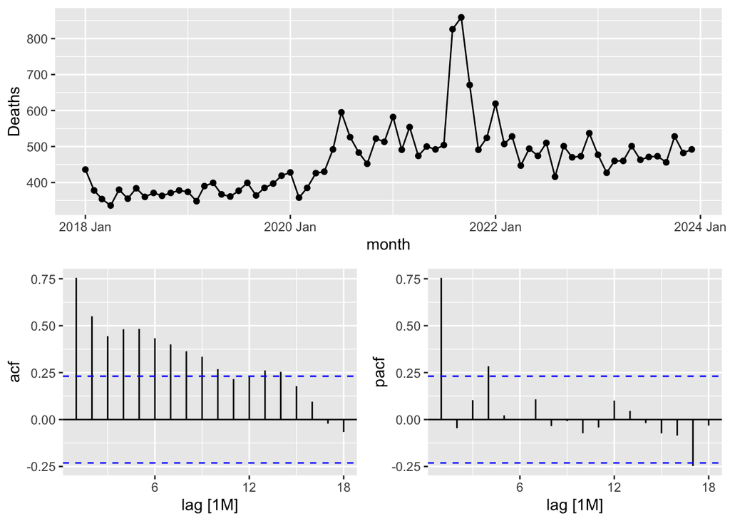

```r
monthly.ts |>
  gg_tsdisplay(y = Deaths, plot_type = "partial")
```

Looking at the PACF and ACF after differencing:

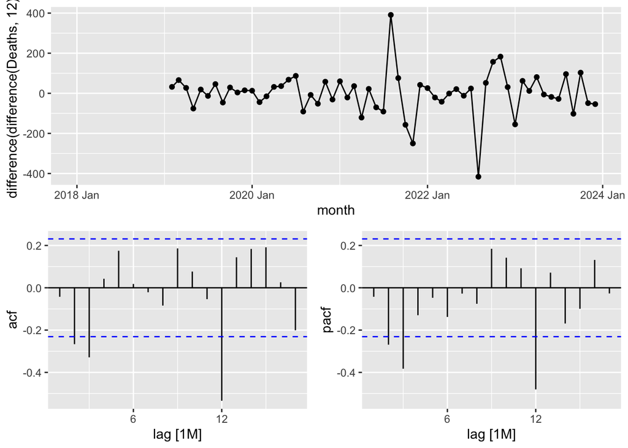

```r
monthly.ts |>
  gg_tsdisplay(y = difference(difference(Deaths,12)), plot_type = "partial")
```

Letting Fable’s ARIMA algorithm choose the best fit…

## 4.1 Intervention effects

We are capturing the intervention effects next - step and ramp variable.

```r
range(monthly.ts$time)
```

```
## [1]  1 72
```

```r
# Create variable representing step and ramp changes
intervention_month <- monthly.ts %>%
  filter(month_year == "2021-05-01") %>%
  pull(time)
monthly.ts <- monthly.ts %>%
  mutate(
    t = row_number(),
    step = if_else(t >= intervention_month, 1, 0),
    ramp = if_else(t >= intervention_month, t - intervention_month + 1, 0)
  )

#View the step and ramp variables
monthly.ts %>%
  pivot_longer(
    cols = c(step, ramp),
    names_to = "variables",
    values_to = "value"
  ) %>%
  ggplot(aes(x = month_year, y = value, color = variables)) +
  geom_line(linewidth = 1) +
  geom_vline(
    xintercept = as.Date("2021-05-01"),
    linetype = "dashed",
    color = "black"
  ) +
  labs(
    title = "Visualizing Step and Ramp Variables",
    x = "Month",
    y = "Value",
    color = ""
  ) +
  scale_x_date(date_breaks = "1 year", date_labels = "%Y") +
  theme_minimal() +
  theme(
    panel.grid.major.x = element_blank(),
    panel.grid.minor.x = element_blank()
  )
```

[output not shown]

## ARIMA model

The Fable algorithm will dictate the model parameters. Next, we plot the residuals, the ACF plot, and a histogram to ensure they approximate a white noise series.

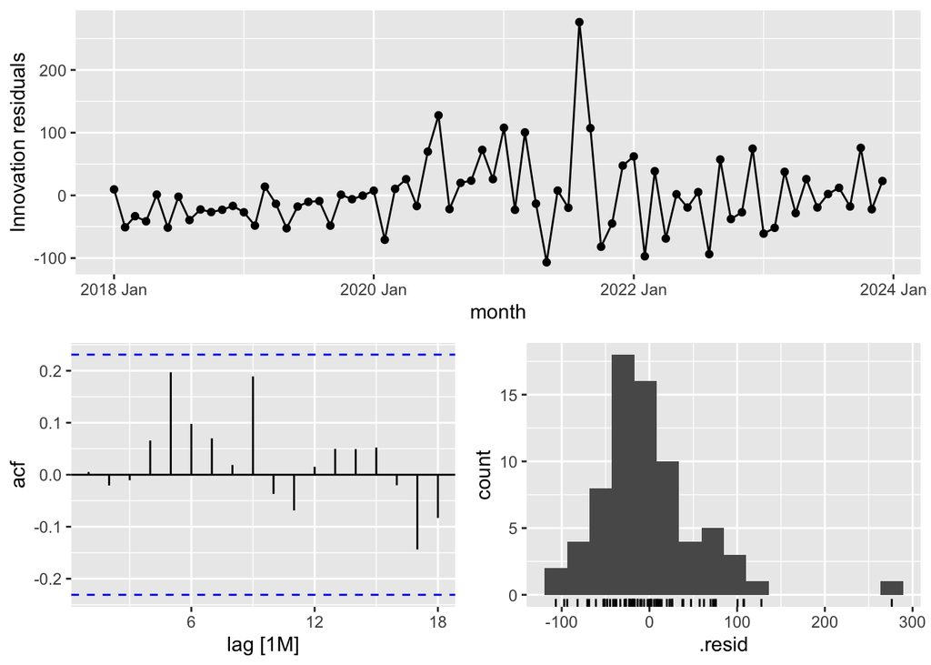

```r
# Use automated algorithm to identify p/q parameters
# Specify first difference = 1 and seasonal difference = 1
m_monthly.ts <- monthly.ts %>%
  model(arima = ARIMA(Deaths ~ step + ramp, stepwise = FALSE))

#Plotting model residuals
m_monthly.ts  %>%
  gg_tsresiduals()
```

There appears to be perhaps a bit of a skew to the data with at least one obvious outlier.

**Need to go in and make sure we meet model assumptions for arima with this**

Here we use the Ljung-Box test, which models if the residuals are still autocorrelated. Null: residuals are independent (white noise) Alternative: residuals show remaining autocorrelation

```r
#Ljung-Box test
augment(m_monthly.ts) %>%
  features(.resid, ljung_box)
```

```
## # A tibble: 1 × 3
##   .model lb_stat lb_pvalue
##   <chr>    <dbl>     <dbl>
## 1 arima  0.00204     0.964
```

This indicates to me that we can safely fail to reject the null, the residuals appear to be independent.

With the model assumptions satisfied, we can take a look at the model estimates:

```r
report(m_monthly.ts)
```

```
## Series: Deaths
## Model: LM w/ ARIMA(0,0,2) errors
##
## Coefficients:
##          ma1     ma2      step     ramp  intercept
##       0.7362  0.4373  153.0607  -3.8810   423.4096
## s.e.  0.1048  0.1055   42.5913   2.1471    19.4289
##
## sigma^2 estimated as 3658:  log likelihood=-395.31
## AIC=802.61   AICc=803.91   BIC=816.27
```

It picked up **p=0**, meaning there is no autoregressive terms.

**d=0**, meaning there is no differencing; the original, raw data is stationary, possessing no trend.

**q=2**: there is are two moving average terms.

The ARIMA estimated an immediate increase in **153 deaths** and an estimated reduction of **-3.88 deaths** each month after Bill 8 was ruled.

Finally, we can run a counter-factual model in which we forecast deaths for 2021-2023 given the model parameters from our initial model, minus the step and ramp parameters. This gives us a visual of what we would have expected had the new policy not come into existence!

```r
#Modeling counterfactual
m_counterfactual <- monthly.ts %>%
  filter(month < make_yearmonth(2021, 5)) %>%
  model(
    arima_null = ARIMA(
      Deaths,
      stepwise = FALSE
    )
  )
report(m_counterfactual)
```

```
## Series: Deaths
## Model: ARIMA(1,1,3)
##
## Coefficients:
##           ar1     ma1      ma2      ma3
##       -0.9682  0.7819  -0.3360  -0.4369
## s.e.   0.0488  0.1774   0.1651   0.1483
##
## sigma^2 estimated as 1392:  log likelihood=-195.42
## AIC=400.84   AICc=402.66   BIC=409.16
```

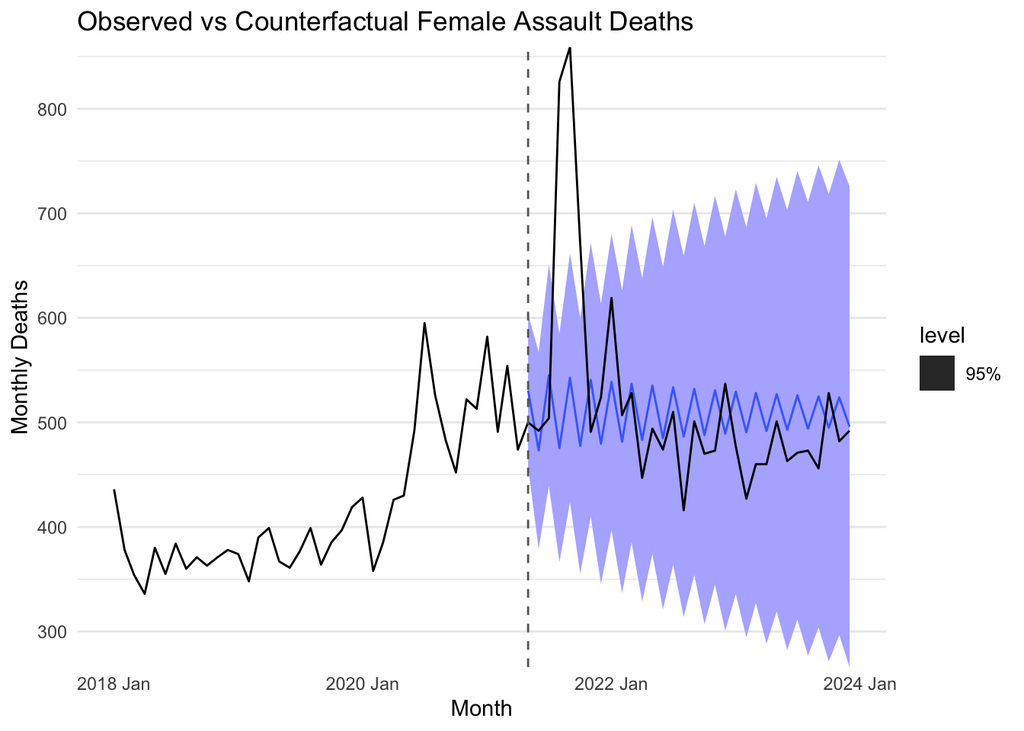

```r
#forecast into post-intervention period
fc_counterfactual <- m_counterfactual %>%
  forecast(h = 28+4)

 autoplot(fc_counterfactual, monthly.ts, level = 95) +
  geom_vline(
    xintercept = as.numeric(as_date(make_yearmonth(2021, 5))),
    linetype = "dashed",
    color = "grey40"
  ) +
  labs(
    title = "Observed vs Counterfactual Female Assault Deaths",
    y = "Monthly Deaths",
    x = "Month"
  ) +
  scale_y_continuous(expand = c(0, 0)) +
  theme_minimal() +
  theme(
    panel.grid.major.x = element_blank(),
    panel.grid.minor.x = element_blank()
  )
```

Huge pop right at sept again.

# 5 National Data

This time we are going to run an arima using **national** data for females aged 15-44 who died of assault. Uploading data and converting to a tsibble object:

```r
monthly <- read.csv("../CleanData/nat_f_assault.csv")
monthly.ts <- monthly %>%
  mutate(month_year = ymd(month_year),
         month = yearmonth(month_year)) %>%
  as_tsibble(index = month)

glimpse(monthly.ts)
```

```
## Rows: 72
## Columns: 5
## $ Deaths     <int> 210, 166, 188, 210, 183, 193, 188, 185, 180, 148, 186, 170,…
## $ month_year <date> 2018-01-01, 2018-02-01, 2018-03-01, 2018-04-01, 2018-05-01…
## $ bill8      <lgl> FALSE, FALSE, FALSE, FALSE, FALSE, FALSE, FALSE, FALSE, FAL…
## $ time       <int> 1, 2, 3, 4, 5, 6, 7, 8, 9, 10, 11, 12, 13, 14, 15, 16, 17, …
## $ month      <mth> 2018 Jan, 2018 Feb, 2018 Mar, 2018 Apr, 2018 May, 2018 Jun,…
```

Looking at data, along with ACF and PACF plots:

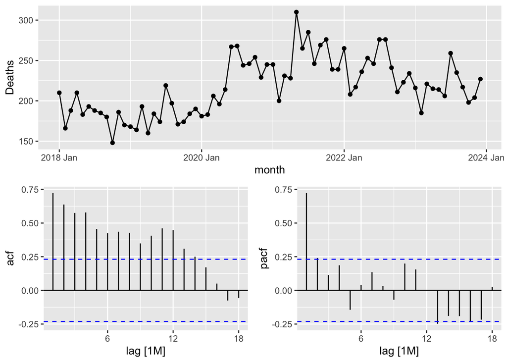

```r
monthly.ts |>
  gg_tsdisplay(y = Deaths, plot_type = "partial")
```

Looking at the PACF and ACF after differencing:

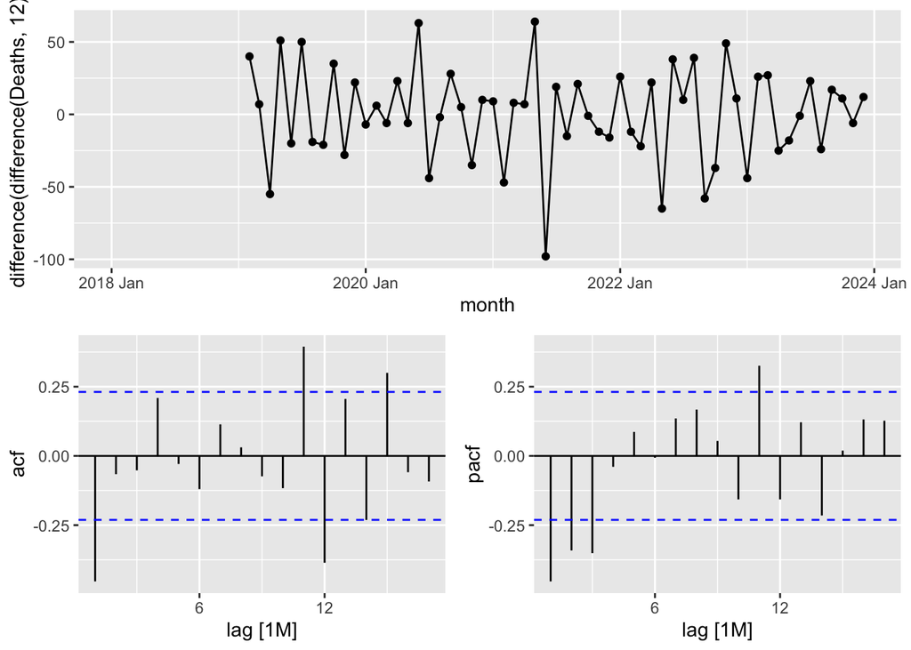

```r
monthly.ts |>
  gg_tsdisplay(y = difference(difference(Deaths,12)), plot_type = "partial")
```

Letting Fable’s ARIMA algorithm choose the best fit…

## 5.1 Intervention effects

We are capturing the intervention effects next - step and ramp variable.

```r
range(monthly.ts$time)
```

```
## [1]  1 72
```

```r
# Create variable representing step and ramp changes
intervention_month <- monthly.ts %>%
  filter(month_year == "2021-05-01") %>%
  pull(time)
monthly.ts <- monthly.ts %>%
  mutate(
    t = row_number(),
    step = if_else(t >= intervention_month, 1, 0),
    ramp = if_else(t >= intervention_month, t - intervention_month + 1, 0)
  )

#View the step and ramp variables
monthly.ts %>%
  pivot_longer(
    cols = c(step, ramp),
    names_to = "variables",
    values_to = "value"
  ) %>%
  ggplot(aes(x = month_year, y = value, color = variables)) +
  geom_line(linewidth = 1) +
  geom_vline(
    xintercept = as.Date("2021-05-01"),
    linetype = "dashed",
    color = "black"
  ) +
  labs(
    title = "Visualizing Step and Ramp Variables",
    x = "Month",
    y = "Value",
    color = ""
  ) +
  scale_x_date(date_breaks = "1 year", date_labels = "%Y") +
  theme_minimal() +
  theme(
    panel.grid.major.x = element_blank(),
    panel.grid.minor.x = element_blank()
  )
```

[output not shown]

## ARIMA model

The Fable algorithm will dictate the model parameters. Next, we plot the residuals, the ACF plot, and a histogram to ensure they approximate a white noise series.

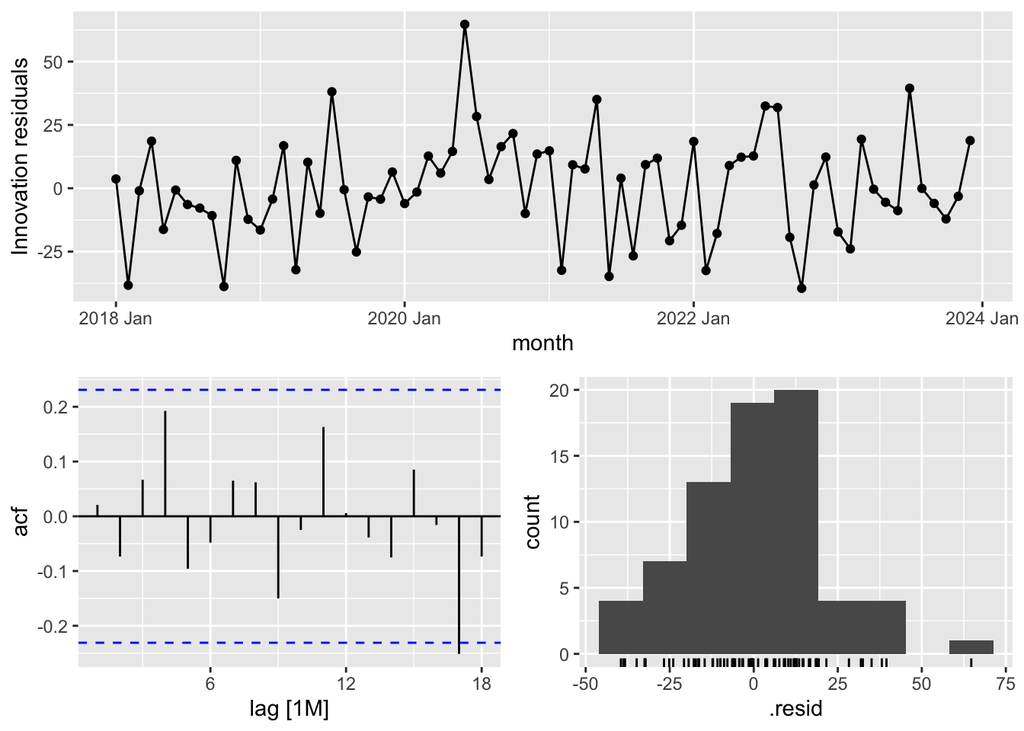

```r
# Use automated algorithm to identify p/q parameters
# Specify first difference = 1 and seasonal difference = 1
m_monthly.ts <- monthly.ts %>%
  model(arima = ARIMA(Deaths ~ step + ramp, stepwise = FALSE))

#Plotting model residuals
m_monthly.ts  %>%
  gg_tsresiduals()
```

Here we use the Ljung-Box test, which models if the residuals are still autocorrelated. Null: residuals are independent (white noise) Alternative: residuals show remaining autocorrelation

```r
#Ljung-Box test
augment(m_monthly.ts) %>%
  features(.resid, ljung_box)
```

```
## # A tibble: 1 × 3
##   .model lb_stat lb_pvalue
##   <chr>    <dbl>     <dbl>
## 1 arima   0.0325     0.857
```

Fail to reject the null.

With the model assumptions satisfied, we can take a look at the model estimates:

```r
report(m_monthly.ts)
```

```
## Series: Deaths
## Model: LM w/ ARIMA(1,0,1)(1,0,0)[12] errors
##
## Coefficients:
##          ar1      ma1    sar1     step     ramp  intercept
##       0.8688  -0.4754  0.2832  50.2895  -1.4666   204.9266
## s.e.  0.0821   0.1558  0.1365  19.8888   0.9903    14.7708
##
## sigma^2 estimated as 450.1:  log likelihood=-319.83
## AIC=653.65   AICc=655.4   BIC=669.59
```

It picked up **p=1**, meaning there is one autoregressive term

**d=0**, meaning there is no differencing; the original, raw data is stationary, possessing no trend.

**q=1**: there is one moving average term, aka the model uses the error from the previous tie step to predict the current value

Seasonality: 1 autoregressive term.

The ARIMA estimated an immediate increase in **50.3 deaths** and an estimated reduction of **-1.47 deaths** each month after Bill 8 was enacted.

Finally, we can run a counter-factual model in which we forecast deaths for 2021-2023 given the model parameters from our initial model, minus the step and ramp parameters. This gives us a visual of what we would have expected had the new policy not come into existence!

```r
#Modeling counterfactual
m_counterfactual <- monthly.ts %>%
  filter(month < make_yearmonth(2021, 5)) %>%
  model(
    arima_null = ARIMA(
      Deaths,
      stepwise = FALSE
    )
  )
report(m_counterfactual)
```

```
## Series: Deaths
## Model: ARIMA(0,1,1)
##
## Coefficients:
##           ma1
##       -0.4887
## s.e.   0.1350
##
## sigma^2 estimated as 440.1:  log likelihood=-173.66
## AIC=351.33   AICc=351.66   BIC=354.65
```

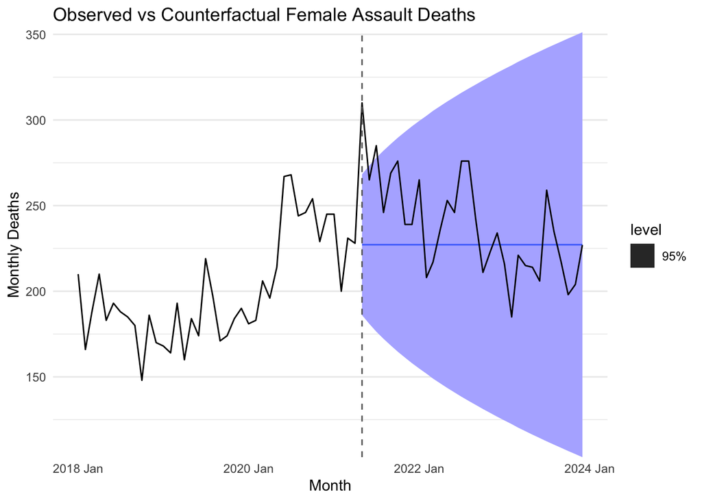

```r
#forecast into post-intervention period
fc_counterfactual <- m_counterfactual %>%
  forecast(h = 28+4)

 autoplot(fc_counterfactual, monthly.ts, level = 95) +
  geom_vline(
    xintercept = as.numeric(as_date(make_yearmonth(2021, 5))),
    linetype = "dashed",
    color = "grey40"
  ) +
  labs(
    title = "Observed vs Counterfactual Female Assault Deaths",
    y = "Monthly Deaths",
    x = "Month"
  ) +
  scale_y_continuous(expand = c(0, 0)) +
  theme_minimal() +
  theme(
    panel.grid.major.x = element_blank(),
    panel.grid.minor.x = element_blank()
  )
```